# ED231D HANDOUT 2: Random Intercept & Random Slope Models

Author

Jordan Rickles

Published

January 21, 2025

# R Walkthrough #2

This handout continues with the example in Chapter 4 of the Raudenbush & Bryk (2002) textbook, which uses the 1982 High School & Beyond (HS&B) Survey data. Throughout the handout, I use “R&B” to refer to the textbook. For this second walkthrough, we’ll use R to conduct the following analyses in Chapter 4:

- Regression with means-as-outcomes
- Random-coefficient model
- Intercept- and slope-as-outcomes model

**Caution**

You should already be familiar with the content covered in Handout #1 and have a basic familiarity with the R statistical programming language before using this handout. The UCLA Statistical Consulting group has an [intro to R seminar available online](https://stats.oarc.ucla.edu/r/seminars/intro/) if you need to become familiar with R.

## 1. Getting Started

To get started, we need to load some R packages and the HS&B data we’ll use for the illustrations.

```r
# clear the R environment just in case there are things loaded that we don't want
# (start with a clean slate)
rm(list=ls())

# load packages
library("lme4") # the primary package we'll use for estimating multilevel models
library("merTools") # package that includes the HS&B data we'll use
library("lmerTest") # another package to add functionality to lme4
library("tidyverse") # optional package useful for data processing
library("skimr") # optional package useful for summarizing data file contents
library("vtable") # optional package useful for creating tables
```

**Note**

If you have not already installed these packages, you will first have to install them before loading the libraries.

## 2. Exploring the Data

Like last time, let’s start by taking a look at the HS&B data … always want to make sure we’re using the correct data.

**Note**

By loading the `merTools` package, you now have access to the HS&B data used in the R&B textbook. The data are in a data frame named `hsb`.

```r
# summary of the data file and variables
skim(hsb)
```

Data summary

| Name | hsb |
| --- | --- |
| Number of rows | 7185 |
| Number of columns | 8 |
| _______________________ |  |
| Column type frequency: |  |
| character | 1 |
| numeric | 7 |
| ________________________ |  |
| Group variables | None |

**Variable type: character**

| skim_variable | n_missing | complete_rate | min | max | empty | n_unique | whitespace |
| --- | --- | --- | --- | --- | --- | --- | --- |
| schid | 0 | 1 | 4 | 4 | 0 | 160 | 0 |

**Variable type: numeric**

| skim_variable | n_missing | complete_rate | mean | sd | p0 | p25 | p50 | p75 | p100 | hist |
| --- | --- | --- | --- | --- | --- | --- | --- | --- | --- | --- |
| minority | 0 | 1 | 0.27 | 0.45 | 0.00 | 0.00 | 0.00 | 1.00 | 1.00 | ▇▁▁▁▃ |
| female | 0 | 1 | 0.53 | 0.50 | 0.00 | 0.00 | 1.00 | 1.00 | 1.00 | ▇▁▁▁▇ |
| ses | 0 | 1 | 0.00 | 0.78 | -3.76 | -0.54 | 0.00 | 0.60 | 2.69 | ▁▁▇▇▁ |
| mathach | 0 | 1 | 12.75 | 6.88 | -2.83 | 7.28 | 13.13 | 18.32 | 24.99 | ▂▆▇▇▆ |
| size | 0 | 1 | 1056.86 | 604.17 | 100.00 | 565.00 | 1016.00 | 1436.00 | 2713.00 | ▇▇▆▂▂ |
| schtype | 0 | 1 | 0.49 | 0.50 | 0.00 | 0.00 | 0.00 | 1.00 | 1.00 | ▇▁▁▁▇ |
| meanses | 0 | 1 | 0.01 | 0.41 | -1.19 | -0.32 | 0.04 | 0.33 | 0.83 | ▁▃▆▇▃ |

This confirms that we have the same number of students (7,185) and schools (160) as the data used in Chapter 4 of R&B. But it looks like the variable in the data file named `schtype` is called `sector` in the book. We should rename the variable to be consistent with the book.

```r
hsb <- hsb %>% rename(sector = schtype)
```

Now let’s create a school-level file to get a better sense of the school-level data.

```r
# create school-level file for reference
hsb.s <- hsb %>%
  group_by(schid) %>%
  summarize(
    meanach = mean(mathach),
    size = mean(size),
    sector = mean(sector),
    meanses = mean(meanses),
    schn = n()
  )

summary(hsb.s)
```

```
    schid              meanach           size            sector
 Length:160         Min.   : 4.24   Min.   : 100.0   Min.   :0.0000
 Class :character   1st Qu.:10.47   1st Qu.: 588.5   1st Qu.:0.0000
 Mode  :character   Median :12.90   Median :1061.0   Median :0.0000
                    Mean   :12.62   Mean   :1097.8   Mean   :0.4375
                    3rd Qu.:14.65   3rd Qu.:1526.0   3rd Qu.:1.0000
                    Max.   :19.72   Max.   :2713.0   Max.   :1.0000
    meanses                schn
 Min.   :-1.1880000   Min.   :14.00
 1st Qu.:-0.3012500   1st Qu.:35.00
 Median : 0.0345000   Median :47.00
 Mean   :-0.0001875   Mean   :44.91
 3rd Qu.: 0.3200000   3rd Qu.:54.00
 Max.   : 0.8310000   Max.   :67.00
```

```r
table(hsb.s$sector)
```

```
 0  1
90 70
```

We’ve confirmed that there are 90 public schools (sector = 0) and 70 Catholic schools (sector = 1), which matches what’s in Chapter 4. Looking at the summary for `schn`, we can also see that there are about 45 students per school on average.

Now let’s try to recreate the summary statistics in Table 4.1.

```r
st(hsb, vars = c("mathach", "ses"),
   numformat = formatfunc(digits = 2, nsmall = 2),
   title = "Replicaiton of summary statistics in Table 4.1: student-level variables")
```

Replicaiton of summary statistics in Table 4.1: student-level variables

| Variable | N | Mean | Std. Dev. | Min | Pctl. 25 | Pctl. 75 | Max |
| --- | --- | --- | --- | --- | --- | --- | --- |
| mathach | 7185 | 12.75 | 6.88 | -2.83 | 7.28 | 18.32 | 24.99 |
| ses | 7185 | 0.00014 | 0.78 | -3.76 | -0.54 | 0.60 | 2.69 |

```r
st(hsb.s, vars = c("sector", "meanses"),
   numformat = formatfunc(digits = 2, nsmall = 2),
   title = "Replicaiton of summary statistics in Table 4.1: school-level variables")
```

Replicaiton of summary statistics in Table 4.1: school-level variables

| Variable | N | Mean | Std. Dev. | Min | Pctl. 25 | Pctl. 75 | Max |
| --- | --- | --- | --- | --- | --- | --- | --- |
| sector | 160 | 0.44 | 0.50 | 0.00 | 0.00 | 1.00 | 1.00 |
| meanses | 160 | -0.00019 | 0.41 | -1.19 | -0.30 | 0.32 | 0.83 |

## 3. Unconditional Model

Before getting to the models of interest for this handout, let’s quickly estimate the unconditional model from Handout #1. Having the results from this model might come in handy later.

```r
# estimate model and save results as m0
m0 <- lmer(mathach ~ 1 + (1 | schid), data = hsb)

# view summary of the model results
summary(m0)
```

```
Linear mixed model fit by REML. t-tests use Satterthwaite's method [
lmerModLmerTest]
Formula: mathach ~ 1 + (1 | schid)
   Data: hsb

REML criterion at convergence: 47116.8

Scaled residuals:
    Min      1Q  Median      3Q     Max
-3.0631 -0.7539  0.0267  0.7606  2.7426

Random effects:
 Groups   Name        Variance Std.Dev.
 schid    (Intercept)  8.614   2.935
 Residual             39.148   6.257
Number of obs: 7185, groups:  schid, 160

Fixed effects:
            Estimate Std. Error       df t value Pr(>|t|)
(Intercept)  12.6370     0.2444 156.6473   51.71   <2e-16 ***
---
Signif. codes:  0 '***' 0.001 '**' 0.01 '*' 0.05 '.' 0.1 ' ' 1
```

```r
# saving variance components for later
vc.m0 <- as.data.frame(VarCorr(m0))
```

## 4. Regression with Means-as-Outcomes

Now let’s jump into the regression with means-as-outcomes model (R&B, p. 72), where we want to use the `lme4` package to estimate the following model.

Level 1: $Y_{ij} = \beta_{0j} + r_{ij}$

Level 2: $\beta_{0j} = \gamma_{00} + \gamma_{01}(MEAN SES)_{j} + u_{0j}$

```r
# estimate model and save results as m1
m1 <- lmer(mathach ~ 1 + meanses + (1 | schid), data = hsb)

# view summary of the model results
summary(m1)
```

```
Linear mixed model fit by REML. t-tests use Satterthwaite's method [
lmerModLmerTest]
Formula: mathach ~ 1 + meanses + (1 | schid)
   Data: hsb

REML criterion at convergence: 46961.3

Scaled residuals:
     Min       1Q   Median       3Q      Max
-3.13480 -0.75256  0.02409  0.76773  2.78501

Random effects:
 Groups   Name        Variance Std.Dev.
 schid    (Intercept)  2.639   1.624
 Residual             39.157   6.258
Number of obs: 7185, groups:  schid, 160

Fixed effects:
            Estimate Std. Error       df t value Pr(>|t|)
(Intercept)  12.6494     0.1493 153.7425   84.74   <2e-16 ***
meanses       5.8635     0.3615 153.4067   16.22   <2e-16 ***
---
Signif. codes:  0 '***' 0.001 '**' 0.01 '*' 0.05 '.' 0.1 ' ' 1

Correlation of Fixed Effects:
        (Intr)
meanses -0.004
```

The model summary has the same results as in Table 4.3 of the R&B textbook:

- Average school mean, $\gamma_{00}$ = 12.65 (SE = 0.15)
- Coefficient for MEAN SES, $\gamma_{01}$ = 5.86 (SE = 0.36)
- School mean variance component, $\tau_{00}$ = 2.64
- Level-1 variance component, $\sigma^2$ = 39.16

However, the `lmer` output does not include the Chi-square test for the random effect term that is reported in Table 4.3. We can get something similar, a likelihood ratio test, with the following R code.

```r
rand(m1)
```

```
ANOVA-like table for random-effects: Single term deletions

Model:
mathach ~ meanses + (1 | schid)
            npar logLik   AIC    LRT Df Pr(>Chisq)
<none>         4 -23481 46969
(1 | schid)    3 -23601 47207 239.95  1  < 2.2e-16 ***
---
Signif. codes:  0 '***' 0.001 '**' 0.01 '*' 0.05 '.' 0.1 ' ' 1
```

This test provides evidence that there is statistically significant between-school variation. Or put differently, a model with school-level random effects fits the data better than a model without the random effects.

To get a better sense of the residual variance between schools, let’s calculate a range of plausible values for the school means (conditional on MEAN SES).

```r
vc <- as.data.frame(VarCorr(m1)) # save variance components

tau_00 <- vc[1,4] # extract the intercept variance component
g_00 <- summary(m1)$coef[1,1] # extract the point estimate for gamma_00

g_00.lb <- g_00 - 1.96*sqrt(tau_00)
g_00.ub <- g_00 + 1.96*sqrt(tau_00)

c(g_00.lb, g_00.ub)
```

```
[1]  9.465592 15.833279
```

And we can calculate the proportion reduction in variance due to including MEAN SES.

```r
tau_00.m0 <- vc.m0[1,4] # grabbing the intercept variance from the unconditional model (Model 0)

(tau_00.m0 - tau_00) / tau_00.m0 # proportion of intercept variance "explained" by MEAN SES
```

```
[1] 0.693673
```

What does the intraclass correlation (ICC) look like after conditioning on MEAN SES?

```r
sig <- vc[2,4]

tau_00 / (tau_00 + sig)
```

```
[1] 0.06313335
```

With the school-level file we created earlier, we can calculate the reliability of the intercept residual for each school ($u_{0j}$), and get the average reliability of the residuals as a summary statistic. Note: this is a “conditional reliability” because the model conditions on MEAN SES.

```r
v0_j <- sig / hsb.s$schn # error variance for school j
lamb_j <- tau_00 / (tau_00 + v0_j)

mean(lamb_j)
```

```
[1] 0.7400747
```

## 5. Random-Coefficient Model

Now we turn to the random-coefficient model (R&B, p. 75), where we want to use the `lme4` package to estimate the following model.

Level 1: $Y_{ij} = \beta_{0j} + \beta_{1j}(X_{ij} - \overline{X}_{.j}) + r_{ij}$

Level 2:

$\beta_{0j} = \gamma_{00} + u_{0j}$

$\beta_{1j} = \gamma_{10} + u_{1j}$

```r
# first group-mean center SES
hsb <- hsb %>% mutate(sesgpm = ses - meanses)

# estimate model and save results as m2
m2 <- lmer(mathach ~ 1 + sesgpm + (1 + sesgpm | schid), data = hsb)

# view summary of the model results
summary(m2)
```

```
Linear mixed model fit by REML. t-tests use Satterthwaite's method [
lmerModLmerTest]
Formula: mathach ~ 1 + sesgpm + (1 + sesgpm | schid)
   Data: hsb

REML criterion at convergence: 46714.2

Scaled residuals:
     Min       1Q   Median       3Q      Max
-3.09680 -0.73194  0.01858  0.75388  2.89928

Random effects:
 Groups   Name        Variance Std.Dev. Corr
 schid    (Intercept)  8.682   2.9465
          sesgpm       0.694   0.8331   0.02
 Residual             36.700   6.0581
Number of obs: 7185, groups:  schid, 160

Fixed effects:
            Estimate Std. Error       df t value Pr(>|t|)
(Intercept)  12.6493     0.2445 156.7391   51.73   <2e-16 ***
sesgpm        2.1932     0.1283 155.2180   17.10   <2e-16 ***
---
Signif. codes:  0 '***' 0.001 '**' 0.01 '*' 0.05 '.' 0.1 ' ' 1

Correlation of Fixed Effects:
       (Intr)
sesgpm 0.012
```

The model summary has the same results as in Table 4.4 of the R&B textbook.

**Note**

There are a couple numbers in our `lmer` output that differ slightly from what’s reported in Table 4.4. For example, the estimate for $\hat{\tau}_{11}$ is 0.68 in Table 4.4 of R&B but is 0.694 in our model output. I believe there are two potential sources for the discrepancy. First, there can be small differences in the underlying estimation methods for `lmer` vs. the HLM program used by R&B that could produce slightly different results. Second, there’s a small discrepancy between the meanses variable included in the HS&B data file and what you get if you calculate school mean SES from the student SES variable. With this second issue, the results from any model that includes a group-mean centered version of student SES is sensitive to how the group-mean centering is done. You should not worry about these minor details/discrepancies. The important thing to take away is how to specify the models using `lmer` and how to extract the desired statistics.

One substantive difference to note in the output is that the `lmer` output does not report the estimate for $\hat{\tau}_{10}$ (the covariance between the intercept and slope random effects). Instead, `lmer` reports the correlation between the intercept and slope random effects. You can use the following code to see the actual covariance estimate.

```r
as.data.frame(VarCorr(m2))
```

```
       grp        var1   var2        vcov      sdcor
1    schid (Intercept)   <NA>  8.68215220 2.94654920
2    schid      sesgpm   <NA>  0.69397694 0.83305278
3    schid (Intercept) sesgpm  0.05079695 0.02069433
4 Residual        <NA>   <NA> 36.70015807 6.05806554
```

The `lmer` output says $\hat{\tau}_{10} = 0.051$, which is a little larger than what’s reported in R&B (0.04). Again, I think this small discrepancy can be attributed to minor differences in the underlying estimation methods for the variance components and/or how the group-mean centering was conducted.

Another thing we might want to do is test whether there is statistically significant between-school variation in the slope term. To do this, we’ll first have to estimate a model with a random intercept but fixed slope. Then we can use a likelihood ratio test to compare the model fit from this more parsimonious model to the fit for the random-coefficient model.

```r
m2x <- lmer(mathach ~ 1 + sesgpm + (1 | schid), data = hsb)

anova(m2x, m2, test = "LRT")
```

```
refitting model(s) with ML (instead of REML)
```

```
Data: hsb
Models:
m2x: mathach ~ 1 + sesgpm + (1 | schid)
m2: mathach ~ 1 + sesgpm + (1 + sesgpm | schid)
    npar   AIC   BIC logLik deviance  Chisq Df Pr(>Chisq)
m2x    4 46728 46756 -23360    46720
m2     6 46723 46764 -23356    46711 9.4331  2   0.008946 **
---
Signif. codes:  0 '***' 0.001 '**' 0.01 '*' 0.05 '.' 0.1 ' ' 1
```

To get a better sense of the between-school variance, let’s calculate a range of plausible values for the school intercepts and slopes.

```r
vc <- as.data.frame(VarCorr(m2)) # save variance components

tau_00 <- vc[1,4] # extract the intercept variance component
tau_11 <- vc[2,4] # extract the slope variance component
g_00 <- summary(m2)$coef[1,1] # extract the point estimate for gamma_00
g_10 <- summary(m2)$coef[2,1] # extract the point estimate for gamma_10

# plausible values for school intercept
g_00.lb <- g_00 - 1.96*sqrt(tau_00)
g_00.ub <- g_00 + 1.96*sqrt(tau_00)

c(g_00.lb, g_00.ub)
```

```
[1]  6.874102 18.424575
```

```r
# plausible values for school slope
g_10.lb <- g_10 - 1.96*sqrt(tau_11)
g_10.ub <- g_10 + 1.96*sqrt(tau_11)

c(g_10.lb, g_10.ub)
```

```
[1] 0.5604091 3.8259760
```

And we can calculate the reliability of the school-level intercept and slope estimates ($\hat{\beta} _{0j}$ and $\hat{\beta} _{1j}$, respectively), and get the average reliabilities as summary statistics. Getting the slope reliabilities, taked a little extra work because we first have to calculate the sum of squares within-school deviations for the group-mean centered SES measure.

```r
ssx <- hsb %>%
  mutate(sesgpm2 = sesgpm^2) %>%
  group_by(schid) %>%
  summarize(ssx = sum(sesgpm2)) %>%
  ungroup()


v0_j <- sig / hsb.s$schn # B0 error variance for school j
v1_j <- sig / ssx$ssx # B1 error variance for school j

lamb0_j <- tau_00 / (tau_00 + v0_j)
lamb1_j <- tau_11 / (tau_11 + v1_j)

mean(lamb0_j) # average reliability for B0_j
```

```
[1] 0.902049
```

```r
mean(lamb1_j) # average reliability for B1_j
```

```
[1] 0.2515922
```

Note: the reliability value we just calculated for $\hat{\beta} _{1j}$ is close but a little off from what’s reported in R&B (p. 78). The discrepancy could be due to the small differences in the variance estimates we get vs. what’s reported in R&B.

One last thing is to calculate the proportion of variance explained at level 1 by including student SES.

```r
sig.m0 <- vc.m0[2,4]

(sig.m0 - sig) / sig.m0
```

```
[1] -0.0002237686
```

## 6. Intercepts- and Slopes-as-Outcomes Model

Now we turn to the intercepts= and slopes-as-outcomes model (R&B, p. 80), where we want to use the `lme4` package to estimate the following model.

Level 1: $Y_{ij} = \beta_{0j} + \beta_{1j}(X_{ij} - \overline{X}_{.j}) + r_{ij}$

Level 2:

$\beta_{0j} = \gamma_{00} + \gamma_{01}(MEAN SES)_j + \gamma_{02}(SECTOR)_j + u_{0j}$

$\beta_{1j} = \gamma_{10} + \gamma_{11}(MEAN SES)_j + \gamma_{12}(SECTOR)_j + u_{1j}$

```r
# estimate model and save results as m3
m3 <- lmer(mathach ~ 1 + meanses + sector + sesgpm + meanses*sesgpm + sector*sesgpm + (1 + sesgpm | schid), data = hsb)

# view summary of the model results
summary(m3)
```

```
Linear mixed model fit by REML. t-tests use Satterthwaite's method [
lmerModLmerTest]
Formula: mathach ~ 1 + meanses + sector + sesgpm + meanses * sesgpm +
    sector * sesgpm + (1 + sesgpm | schid)
   Data: hsb

REML criterion at convergence: 46503.7

Scaled residuals:
     Min       1Q   Median       3Q      Max
-3.15921 -0.72319  0.01706  0.75439  2.95822

Random effects:
 Groups   Name        Variance Std.Dev. Corr
 schid    (Intercept)  2.3819  1.5433
          sesgpm       0.1014  0.3184   0.39
 Residual             36.7211  6.0598
Number of obs: 7185, groups:  schid, 160

Fixed effects:
               Estimate Std. Error       df t value Pr(>|t|)
(Intercept)     12.1136     0.1988 159.8921  60.931  < 2e-16 ***
meanses          5.3391     0.3693 150.9689  14.457  < 2e-16 ***
sector           1.2167     0.3064 149.5994   3.971 0.000111 ***
sesgpm           2.9388     0.1551 139.3042  18.948  < 2e-16 ***
meanses:sesgpm   1.0389     0.2989 160.5528   3.476 0.000656 ***
sector:sesgpm   -1.6426     0.2398 143.3449  -6.850 2.01e-10 ***
---
Signif. codes:  0 '***' 0.001 '**' 0.01 '*' 0.05 '.' 0.1 ' ' 1

Correlation of Fixed Effects:
            (Intr) meanss sector sesgpm mnss:s
meanses      0.245
sector      -0.697 -0.356
sesgpm       0.080  0.020 -0.056
menss:ssgpm  0.019  0.079 -0.028  0.282
sectr:ssgpm -0.056 -0.029  0.082 -0.694 -0.351
```

```r
# print the parameter variance and covariance estimates
as.data.frame(VarCorr(m3))
```

```
       grp        var1   var2       vcov     sdcor
1    schid (Intercept)   <NA>  2.3818707 1.5433310
2    schid      sesgpm   <NA>  0.1013640 0.3183772
3    schid (Intercept) sesgpm  0.1925874 0.3919466
4 Residual        <NA>   <NA> 36.7211313 6.0597963
```

The model summary results align with the results in Table 4.5 of the R&B textbook, with the exception of some minor differences as noted with other models that use the group-mean centered version of student SES.

Now let’s test whether including the random slope (and covariance) improves model fit compared to a model that just has a random intercept.

```r
m3x <- lmer(mathach ~ 1 + meanses + sector + sesgpm + meanses*sesgpm + sector*sesgpm + (1 | schid), data = hsb)

anova(m3x, m3, test = "LRT")
```

```
refitting model(s) with ML (instead of REML)
```

```
Data: hsb
Models:
m3x: mathach ~ 1 + meanses + sector + sesgpm + meanses * sesgpm + sector * sesgpm + (1 | schid)
m3: mathach ~ 1 + meanses + sector + sesgpm + meanses * sesgpm + sector * sesgpm + (1 + sesgpm | schid)
    npar   AIC   BIC logLik deviance  Chisq Df Pr(>Chisq)
m3x    8 46513 46568 -23249    46497
m3    10 46516 46585 -23248    46496 1.0037  2     0.6054
```

The results of this likelihood ratio test suggest that including the random slope (and covariance) parameters does not significantly improve the model fit. Therefore, one could argue that it is better to fix the SES-achievement slope and only estimate a random-intercept model.

One more thing to do is calculate the proportion of variance explained by the level 2 covariates included in the intercept and slope models. For these calculations, we compare the parameter variance from the intercepts- and slopes-as-outcomes model (Model 3) to the parameter variance from the random-coefficient model (Model 2).

```r
# get parameter variance estimates from Model 2
vc.m2 <- as.data.frame(VarCorr(m2)) # save variance components

tau_00.m2 <- vc.m2[1,4] # extract the intercept variance component
tau_11.m2 <- vc.m2[2,4] # extract the slope variance component

# get parameter variance estimates from Model 3
vc.m3 <- as.data.frame(VarCorr(m3)) # save variance components

tau_00.m3 <- vc.m3[1,4] # extract the intercept variance component
tau_11.m3 <- vc.m3[2,4] # extract the slope variance component

# proportion of intercept variance explained
(tau_00.m2 - tau_00.m3) / tau_00.m2
```

```
[1] 0.725659
```

```r
# proportion of intercept variance explained
(tau_11.m2 - tau_11.m3) / tau_11.m2
```

```
[1] 0.8539375
```

Again, our results for the intercept perfectly match what’s reported in R&B, but the estimate we get for the slope variance is a bit different. Our calculations should be correct and the discrepancy can be attributed to minor differences in the underlying estimation methods for the variance components and/or how the group-mean centering was conducted.

## 7. Extracting Level-2 Residuals and Empircal Bayes Estimates to Further Investigate Variation at Level 2

While not directly part of the R&B Chapter 4 illustration, I think it’s useful to know how to extract the level-2 residuals ($\hat{u}_{0j}$ and $\hat{u}_{1j}$) and the empirical Bayes (EB) parameter estimates ($\beta^*_{0j}$ and $\beta^*_{1j}$) to conduct some exploratory checks and further investigate variation at level 2. We’ll work with the Model 3 residuals to demonstrate the R code.

Let’s start by extracting the residuals and their standard errors.

```r
# extract residuals
re3 <- ranef(m3, condVar=TRUE, whichel = "schid")
red3 <- as.data.frame(re3)

head(red3)
```

```
  grpvar        term  grp     condval    condsd
1  schid (Intercept) 1224 -0.07265550 0.7666102
2  schid (Intercept) 1288  0.45684086 0.9526734
3  schid (Intercept) 1296 -1.71293159 0.7604572
4  schid (Intercept) 1308  0.03100532 1.0181153
5  schid (Intercept) 1317 -1.53192099 0.7606536
6  schid (Intercept) 1358 -0.49151374 0.8986626
```

The resulting file is a little confusing. There’s a row for each school x each random effect term. The *condval* column is the random effect estimate and the *condsd* column is the standard error for that random effect estimate. *grp* is the school ID.

Let’s clean this up a bit to get it in a format that’s more user-friendly. While we’re at it, we’ll also calculate the 95% confidence interval for the random effects.

```r
# clean up the intercept residuals & calculate confidence intervals
U0 <- red3 %>% filter(term == "(Intercept)") %>%
  select(u0j = condval, u0j.se = condsd) %>%
  mutate(u0j.lb = u0j - 1.96*u0j.se,
         u0j.ub = u0j + 1.96*u0j.se)

# clean up the slope residuals & calculate confidence intervals
U1 <- red3 %>% filter(term == "sesgpm") %>%
  select(u1j = condval, u1j.se = condsd) %>%
  mutate(u1j.lb = u1j - 1.96*u1j.se,
         u1j.ub = u1j + 1.96*u1j.se)
```

Now let’s get the empirical Bayes estimates.

```r
B <- as.data.frame(coef(m3)$schid) # extracts all coefficient estimates (fixed and random)

# clean up the file and save just the EB estimates and school ID
B <- B %>%
  mutate(schid = as.numeric(rownames(B))) %>%
  rename(EB0j = `(Intercept)`,
         EB1j = sesgpm) %>%
  select(schid, EB0j, EB1j)

# put the EB estimates and random effect estimates into one data file
B <- cbind(B, U0, U1)

# take a look at what we have
head(B)
```

```
     schid     EB0j     EB1j         u0j    u0j.se    u0j.lb      u0j.ub
1224  1224 12.04093 2.933729 -0.07265550 0.7666102 -1.575211  1.42990040
1288  1288 12.57043 2.979196  0.45684086 0.9526734 -1.410399  2.32408066
1296  1296 10.40065 2.743957 -1.71293159 0.7604572 -3.203428 -0.22243555
1308  1308 12.14459 2.923780  0.03100532 1.0181153 -1.964501  2.02651137
1317  1317 10.58166 2.806556 -1.53192099 0.7606536 -3.022802 -0.04103986
1358  1358 11.62207 2.961264 -0.49151374 0.8986626 -2.252892  1.26986493
              u1j    u1j.se     u1j.lb    u1j.ub
1224 -0.005033286 0.2931029 -0.5795150 0.5694485
1288  0.040433249 0.2989793 -0.5455662 0.6264327
1296 -0.194805777 0.2924551 -0.7680179 0.3784063
1308 -0.014982429 0.3026724 -0.6082203 0.5782555
1317 -0.132206372 0.2942241 -0.7088855 0.4444728
1358  0.022501933 0.2972946 -0.5601955 0.6051994
```

```r
skim(B)
```

Data summary

| Name | B |
| --- | --- |
| Number of rows | 160 |
| Number of columns | 11 |
| _______________________ |  |
| Column type frequency: |  |
| numeric | 11 |
| ________________________ |  |
| Group variables | None |

**Variable type: numeric**

| skim_variable | n_missing | complete_rate | mean | sd | p0 | p25 | p50 | p75 | p100 | hist |
| --- | --- | --- | --- | --- | --- | --- | --- | --- | --- | --- |
| schid | 0 | 1 | 5309.99 | 2547.68 | 1224.00 | 3018.25 | 5511.50 | 7431.75 | 9586.00 | ▇▇▅▆▇ |
| EB0j | 0 | 1 | 12.11 | 1.31 | 8.39 | 11.29 | 12.08 | 12.96 | 16.27 | ▁▆▇▃▁ |
| EB1j | 0 | 1 | 2.94 | 0.12 | 2.60 | 2.85 | 2.94 | 3.02 | 3.31 | ▁▅▇▅▁ |
| u0j | 0 | 1 | 0.00 | 1.31 | -3.72 | -0.82 | -0.04 | 0.85 | 4.16 | ▁▆▇▃▁ |
| u0j.se | 0 | 1 | 0.79 | 0.09 | 0.67 | 0.73 | 0.77 | 0.85 | 1.12 | ▇▆▃▁▁ |
| u0j.lb | 0 | 1 | -1.55 | 1.33 | -5.91 | -2.43 | -1.49 | -0.72 | 2.68 | ▁▃▇▃▁ |
| u0j.ub | 0 | 1 | 1.55 | 1.32 | -2.01 | 0.71 | 1.45 | 2.48 | 5.64 | ▁▆▇▃▁ |
| u1j | 0 | 1 | 0.00 | 0.12 | -0.34 | -0.09 | 0.01 | 0.08 | 0.38 | ▁▅▇▅▁ |
| u1j.se | 0 | 1 | 0.29 | 0.00 | 0.29 | 0.29 | 0.29 | 0.30 | 0.30 | ▃▇▆▃▁ |
| u1j.lb | 0 | 1 | -0.57 | 0.12 | -0.94 | -0.67 | -0.57 | -0.49 | -0.20 | ▁▅▇▅▁ |
| u1j.ub | 0 | 1 | 0.57 | 0.12 | 0.23 | 0.48 | 0.58 | 0.66 | 0.95 | ▁▅▇▅▁ |

Now let’s look at a few different plots of the EB estimates and residuals.

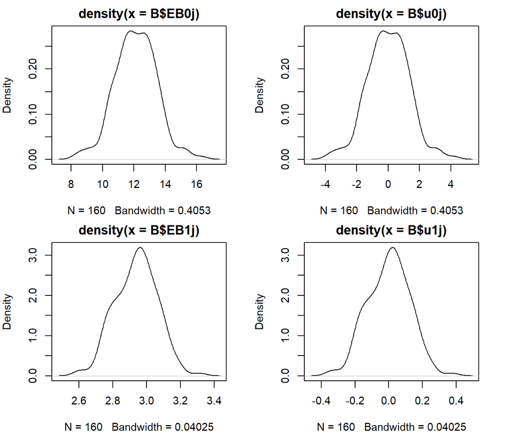

```r
# DENSITY PLOTS
par(mfrow = c(2, 2), mar=c(4,4,2,2), cex=0.9)
plot(density(B$EB0j))
plot(density(B$u0j))
plot(density(B$EB1j))
plot(density(B$u1j))
```

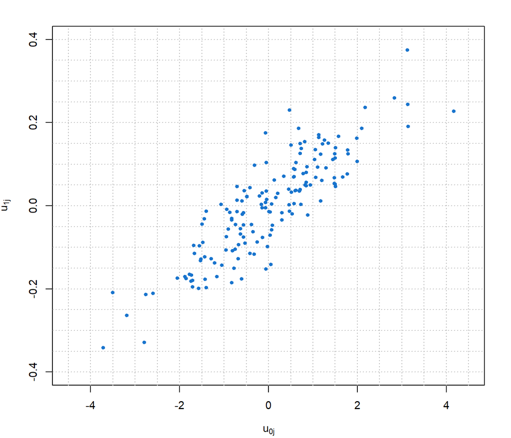

```r
# SCATTER PLOT OF U0 AND U1 RESIDUALS
xax <- seq(-4.5, 4.5, 0.5)
yax <- seq(-0.4, 0.4, 0.05)

par(mfrow = c(1, 1), mar=c(4,4,2,2), cex=0.9)
plot(NULL,main = "", xlab = expression(u[0][j]), ylab = expression(u[1][j]),
     ylim = c(min(yax), max(yax)), xlim = c(min(xax), max(xax)))
abline(h = yax, lty = 3, col = "grey") #add line for yax intervals
abline(v = xax, lty = 3, col = "grey") #add line for xax intervals
points(B$u0j, B$u1j, pch = 20, col = "dodgerblue3", cex = 1.0) # add points
```

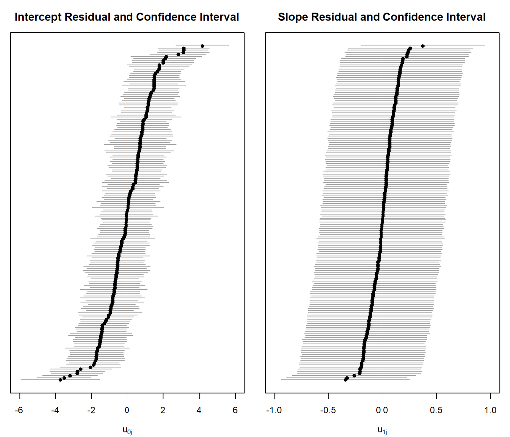

```r
# CATERPILLAR PLOT OF RESIDUALS
index <- 1:nrow(B)

par(mfrow = c(1, 2), mar=c(4, 1, 3, 1), cex=0.75)

# intercept residual
xax <- seq(-6, 6, 0.5)

B <- B %>% arrange(u0j)

plot(NULL, main = "Intercept Residual and Confidence Interval",
     xlab = expression(u[0][j]), ylab = "",
     ylim = c(min(index), max(index)), xlim = c(min(xax), max(xax)), yaxt = "n")

segments(B$u0j.lb, index, B$u0j.ub, index, lend = 3, lwd = 1, col = "darkgrey") # add confidence interval
abline(v = 0, lty = 1, lwd = 1, col = "dodgerblue") #add line for mean
points(B$u0j, index, pch = 21, col = "black", bg = "black", cex = 0.8) # add point estimate

# slope residual
xax <- seq(-1, 1, 0.20)

B <- B %>% arrange(u1j)

plot(NULL, main = "Slope Residual and Confidence Interval",
     xlab = expression(u[1][j]), ylab = "",
     ylim = c(min(index), max(index)), xlim = c(min(xax), max(xax)), yaxt = "n")

segments(B$u1j.lb, index, B$u1j.ub, index, lend = 3, lwd = 1, col = "darkgrey") # add confidence interval
abline(v = 0, lty = 1, lwd = 1, col = "dodgerblue") #add line for mean
points(B$u1j, index, pch = 21, col = "black", bg = "black", cex = 0.8) # add point estimate
```